# lab1

Marco Bresciani

2022-08-02

# REGRESSIONE LINEARE SEMPLICE

Il modello di regressione lineare non richiede né che la variabile dipendente (la y) né che le variabili indipendenti (le x) abbiano una distribuzione Normale.

Quello che in realtà richiede il modello è che gli errori siano tra loro indipendenti ed identicamente distribuiti (in gergo tecnico i.i.d.) in modo approssimabile ad una distribuzione Normale con media pari a 0 e varianza pari a σ ²

```r
library(car)
getwd()
```

```
## [1] "C:/Users/Marco/Documents/UNIVE/3/ANALISI PREDITTIVA/R files/Lab 01-2/doneByMe"
```

```r
#Leggo il dataset Rent per l'affitto di case a Monaco
tRents<-read.table("../../data/rent99.raw", header=TRUE)
summary(tRents)
```

```
##       rent            rentsqm             area            yearc
##  Min.   :  40.51   Min.   : 0.4158   Min.   : 20.00   Min.   :1918
##  1st Qu.: 322.03   1st Qu.: 5.2610   1st Qu.: 51.00   1st Qu.:1939
##  Median : 426.97   Median : 6.9802   Median : 65.00   Median :1959
##  Mean   : 459.44   Mean   : 7.1113   Mean   : 67.37   Mean   :1956
##  3rd Qu.: 559.36   3rd Qu.: 8.8408   3rd Qu.: 81.00   3rd Qu.:1972
##  Max.   :1843.38   Max.   :17.7216   Max.   :160.00   Max.   :1997
##     location          bath            kitchen          cheating
##  Min.   :1.000   Min.   :0.00000   Min.   :0.0000   Min.   :0.0000
##  1st Qu.:1.000   1st Qu.:0.00000   1st Qu.:0.0000   1st Qu.:1.0000
##  Median :1.000   Median :0.00000   Median :0.0000   Median :1.0000
##  Mean   :1.443   Mean   :0.06197   Mean   :0.0425   Mean   :0.8958
##  3rd Qu.:2.000   3rd Qu.:0.00000   3rd Qu.:0.0000   3rd Qu.:1.0000
##  Max.   :3.000   Max.   :1.00000   Max.   :1.0000   Max.   :1.0000
##     district
##  Min.   : 113
##  1st Qu.: 561
##  Median :1025
##  Mean   :1170
##  3rd Qu.:1714
##  Max.   :2529
```

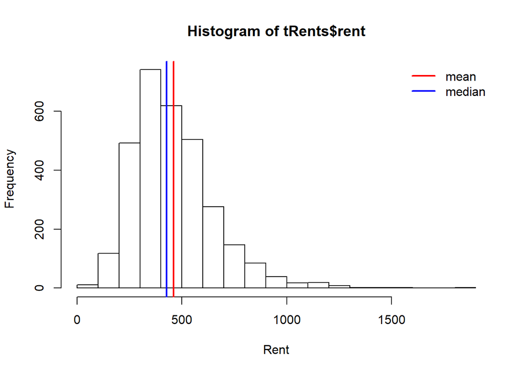

```r
#la variabile di interesse è "rent", visualizzamo la distribuzione con un ISTOGRAMMA
hist(tRents$rent, xlab = "Rent")
#visualizziamo media e mediana
mean_tRents <- mean(tRents$rent)
median_tRents <- median(tRents$rent)
#tracciamole con comando "abline"
hist(tRents$rent, xlab = "Rent")
abline(v=mean_tRents, col=2, lwd=2) #v = vertical Line #h = horizontal line
abline(v=median_tRents, col=4, lwd = 2)
legend("topright", bty = "n", col = c(2,4),lwd = 2,
       legend = c("mean","median"))
```

```r
summary(tRents$rent[tRents$kitchen==0]) #0 -> cucina standard
```

```
##    Min. 1st Qu.  Median    Mean 3rd Qu.    Max.
##   40.51  319.41  421.33  452.55  548.41 1843.38
```

```r
summary(tRents$rent[tRents$kitchen==1]) #1 -> cucina premium
```

```
##    Min. 1st Qu.  Median    Mean 3rd Qu.    Max.
##   133.3   448.1   616.3   614.7   748.5  1459.2
```

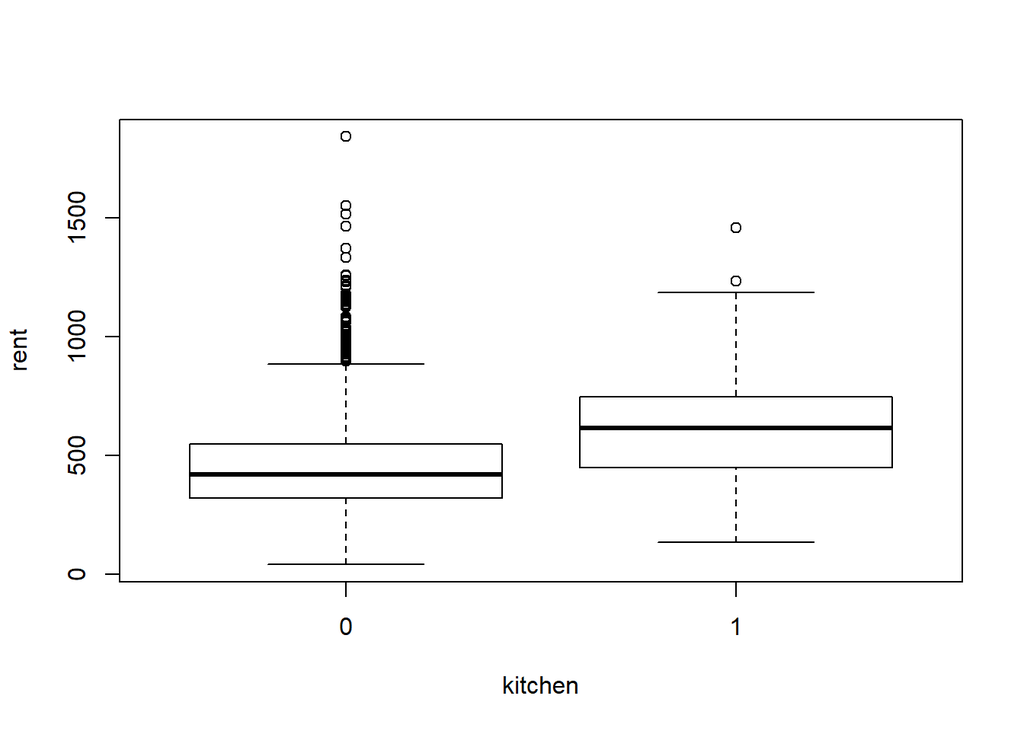

```r
boxplot(rent~kitchen, data=tRents)
```

notiamo il cambiamento del prezzo di affitto in relazione alla tipologia di cucina proviamo a vedere come cambia per i bagni

```r
summary(tRents$rent[tRents$bath==0])
```

```
##    Min. 1st Qu.  Median    Mean 3rd Qu.    Max.
##   40.51  315.08  418.00  446.79  543.79 1843.38
```

```r
summary(tRents$rent[tRents$bath==1])
```

```
##    Min. 1st Qu.  Median    Mean 3rd Qu.    Max.
##   177.9   461.2   586.8   650.8   818.8  1551.2
```

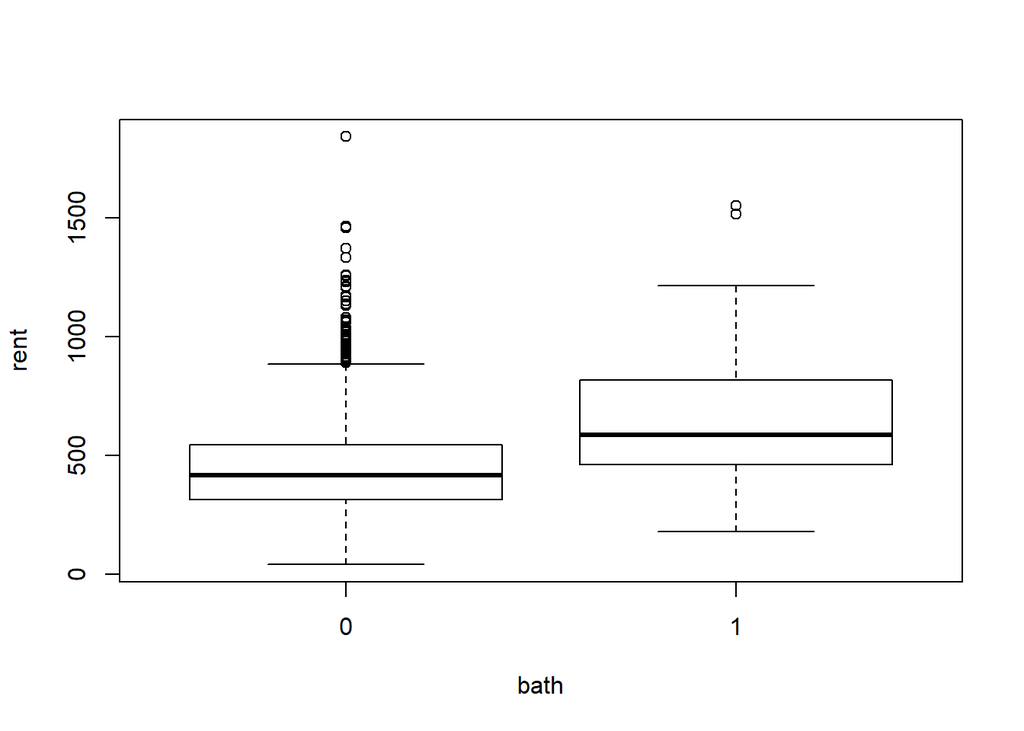

```r
boxplot(rent~bath, data= tRents)
```

```r
#invece per la location
summary(tRents$rent[tRents$location==1])
```

```
##    Min. 1st Qu.  Median    Mean 3rd Qu.    Max.
##   54.92  313.36  415.26  435.88  529.23 1459.23
```

```r
summary(tRents$rent[tRents$location==2])
```

```
##    Min. 1st Qu.  Median    Mean 3rd Qu.    Max.
##   40.51  331.27  443.15  482.99  597.27 1843.38
```

```r
summary(tRents$rent[tRents$location==3])
```

```
##    Min. 1st Qu.  Median    Mean 3rd Qu.    Max.
##   179.5   384.3   646.2   636.0   849.9  1210.9
```